# Accelerating tidy list-column workflows with collateral

James Goldie

2018-11-09

The [`purrr`](https://purrr.tidyverse.org) package has a comprehensive set of tools for wrking with lists and vectors, and especially for iterating operations and analyses with its [`map()`](https://purrr.tidyverse.org/reference/map.html). This style of iteration is particularly powerful when used with the [`tibble`](https://tibble.tidyverse.org/) package, because—unlike regular data frames—tibbles allow you to use lists as data frame columns as well as vectors. That means that complex objects, including models, plots and even other data frames can be stored inside a data frame list-column alongside other data.

The biggest downside of being able to do complex analysis on many list elements is that one little error can bring a lot of computation down. Another is that a warning or other message might get lost: if the 37th sttaistical model you fit of 45 has a problem, are you going to catch it?

`purrr` comes with tools for dealing with errors, warnings and other “side effects”, but it’s difficult to pair them effectively with `purrr`’s massively powerful iteration tools. And that’s where `collateral` comes in: it gives you ways to drop-in replacements for `map()` that use employ these side-effect capturing tools, as well as an array of other helpers to make navigating everything you’ve captured more pleasant.

# Basic exploratory analysis

The aim of this vignette isn’t just to get you acquainted with `collateral`’s tools: it’s also to demonstrate the value of a tidy list-column workflow. We’ll be using the `diamonds` dataset, which comes with the [`ggplot2`](https://ggplot2.tidyverse.org) package. Let’s take a look:

```r
library(tidyverse)
diamonds
```

```
#> # A tibble: 53,940 x 10
#>    carat cut       color clarity depth table price     x     y     z
#>    <dbl> <ord>     <ord> <ord>   <dbl> <dbl> <int> <dbl> <dbl> <dbl>
#>  1 0.23  Ideal     E     SI2      61.5    55   326  3.95  3.98  2.43
#>  2 0.21  Premium   E     SI1      59.8    61   326  3.89  3.84  2.31
#>  3 0.23  Good      E     VS1      56.9    65   327  4.05  4.07  2.31
#>  4 0.290 Premium   I     VS2      62.4    58   334  4.2   4.23  2.63
#>  5 0.31  Good      J     SI2      63.3    58   335  4.34  4.35  2.75
#>  6 0.24  Very Good J     VVS2     62.8    57   336  3.94  3.96  2.48
#>  7 0.24  Very Good I     VVS1     62.3    57   336  3.95  3.98  2.47
#>  8 0.26  Very Good H     SI1      61.9    55   337  4.07  4.11  2.53
#>  9 0.22  Fair      E     VS2      65.1    61   337  3.87  3.78  2.49
#> 10 0.23  Very Good H     VS1      59.4    61   338  4     4.05  2.39
#> # ... with 53,930 more rows
```

This dataset describes the prices and properties of about fifty thousand diamonds. We can see a number of categorical variables, including `cut`, `color` and `clarity`, and several continuous variables, like the `price`.

How is `price` distributed?

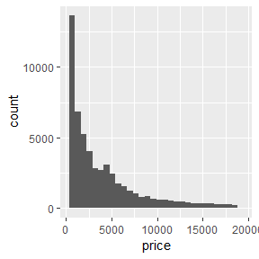

```r
ggplot(diamonds) +
  geom_histogram(aes(x = price, y = stat(count)))
```

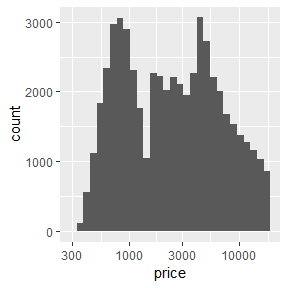

```r
ggplot(diamonds) +
  geom_histogram(aes(x = price, y = stat(count))) +
  scale_x_log10()
```

Looking at a histogram with a logarithmic scale, we can see that it has multiple peaks. That probably means that there are several distinct groups in the data. Maybe there’s a relationship between `price` and one (or more) of the categorical variables.

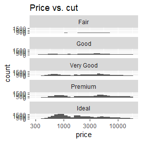

```r
ggplot(diamonds) +
  geom_histogram(aes(x = price, y = stat(count))) +
  facet_wrap(vars(cut), ncol = 1) +
  scale_x_log10() +
  ggtitle('Price vs. cut')
```

[figure not shown]

```r
ggplot(diamonds) +
  geom_histogram(aes(x = price, y = stat(count))) +
  facet_wrap(vars(color), ncol = 1) +
  scale_x_log10() +
  ggtitle('Price vs. color')
```

# Grouping the traditional way

It looks like there might be several relationships here, but let’s focus on `cut` and `color` for now. `ggplot2` makes it very easy to visualise differences across a couple of grouping variables, but we may not always want to create a facetted plot—in fact, there may be lots of activities we want to do that don’t involve plotting at all.

This is a broad class of problem in data analysis called [‘split-apply-combine’](https://4dpiecharts.com/2011/12/16/a-quick-primer-on-split-apply-combine-problems/): *split* data up into groups, *apply* operations to those groups and *combine* the results. One way of doing this with base R is to use [`split()`](https://stat.ethz.ch/R-manual/R-devel/library/base/html/split.html), which takes in a data frame and some grouping variables and gives you back a list of identically-structured data frames broken up row-wise ccording to the values of the grouping variables.

```r
diamonds %>% split(diamonds$cut)
```

```
#> $Fair
#> # A tibble: 1,610 x 10
#>    carat cut   color clarity depth table price     x     y     z
#>    <dbl> <ord> <ord> <ord>   <dbl> <dbl> <int> <dbl> <dbl> <dbl>
#>  1  0.22 Fair  E     VS2      65.1    61   337  3.87  3.78  2.49
#>  2  0.86 Fair  E     SI2      55.1    69  2757  6.45  6.33  3.52
#>  3  0.96 Fair  F     SI2      66.3    62  2759  6.27  5.95  4.07
#>  4  0.7  Fair  F     VS2      64.5    57  2762  5.57  5.53  3.58
#>  5  0.7  Fair  F     VS2      65.3    55  2762  5.63  5.58  3.66
#>  6  0.91 Fair  H     SI2      64.4    57  2763  6.11  6.09  3.93
#>  7  0.91 Fair  H     SI2      65.7    60  2763  6.03  5.99  3.95
#>  8  0.98 Fair  H     SI2      67.9    60  2777  6.05  5.97  4.08
#>  9  0.84 Fair  G     SI1      55.1    67  2782  6.39  6.2   3.47
#> 10  1.01 Fair  E     I1       64.5    58  2788  6.29  6.21  4.03
#> # ... with 1,600 more rows
#>
#> $Good
#> # A tibble: 4,906 x 10
#>    carat cut   color clarity depth table price     x     y     z
#>    <dbl> <ord> <ord> <ord>   <dbl> <dbl> <int> <dbl> <dbl> <dbl>
#>  1  0.23 Good  E     VS1      56.9    65   327  4.05  4.07  2.31
#>  2  0.31 Good  J     SI2      63.3    58   335  4.34  4.35  2.75
#>  3  0.3  Good  J     SI1      64      55   339  4.25  4.28  2.73
#>  4  0.3  Good  J     SI1      63.4    54   351  4.23  4.29  2.7
#>  5  0.3  Good  J     SI1      63.8    56   351  4.23  4.26  2.71
#>  6  0.3  Good  I     SI2      63.3    56   351  4.26  4.3   2.71
#>  7  0.23 Good  F     VS1      58.2    59   402  4.06  4.08  2.37
#>  8  0.23 Good  E     VS1      64.1    59   402  3.83  3.85  2.46
#>  9  0.31 Good  H     SI1      64      54   402  4.29  4.31  2.75
#> 10  0.26 Good  D     VS2      65.2    56   403  3.99  4.02  2.61
#> # ... with 4,896 more rows
#>
#> $`Very Good`
#> # A tibble: 12,082 x 10
#>    carat cut       color clarity depth table price     x     y     z
#>    <dbl> <ord>     <ord> <ord>   <dbl> <dbl> <int> <dbl> <dbl> <dbl>
#>  1  0.24 Very Good J     VVS2     62.8    57   336  3.94  3.96  2.48
#>  2  0.24 Very Good I     VVS1     62.3    57   336  3.95  3.98  2.47
#>  3  0.26 Very Good H     SI1      61.9    55   337  4.07  4.11  2.53
#>  4  0.23 Very Good H     VS1      59.4    61   338  4     4.05  2.39
```

[output cut: 24 more lines]

```
#> $Ideal
#> # A tibble: 21,551 x 10
#>    carat cut   color clarity depth table price     x     y     z
#>    <dbl> <ord> <ord> <ord>   <dbl> <dbl> <int> <dbl> <dbl> <dbl>
#>  1  0.23 Ideal E     SI2      61.5    55   326  3.95  3.98  2.43
#>  2  0.23 Ideal J     VS1      62.8    56   340  3.93  3.9   2.46
#>  3  0.31 Ideal J     SI2      62.2    54   344  4.35  4.37  2.71
#>  4  0.3  Ideal I     SI2      62      54   348  4.31  4.34  2.68
#>  5  0.33 Ideal I     SI2      61.8    55   403  4.49  4.51  2.78
#>  6  0.33 Ideal I     SI2      61.2    56   403  4.49  4.5   2.75
#>  7  0.33 Ideal J     SI1      61.1    56   403  4.49  4.55  2.76
#>  8  0.23 Ideal G     VS1      61.9    54   404  3.93  3.95  2.44
#>  9  0.32 Ideal I     SI1      60.9    55   404  4.45  4.48  2.72
#> 10  0.3  Ideal I     SI2      61      59   405  4.3   4.33  2.63
#> # ... with 21,541 more rows
```

As it happens, the `purrr::map()` functions work quite well on the output of `split()`:

```r
diamonds %>%
  split(diamonds$cut) %>%
  map_dbl(~ mean(.$price))
```

```
#>      Fair      Good Very Good   Premium     Ideal
#>  4358.758  3928.864  3981.760  4584.258  3457.542
```

But this starts to get really unwieldy as you add more grouping variables. In particular, “meta data”— data about the groups—is either stuck inside the original data frames or is encoded in the name of each data frame in the list. It’s also difficult to do a sequence of operations and keep everything associated with the original groupings:

```r
diamonds_list = diamonds %>% split(list(diamonds$cut, diamonds$color))

map_dbl(diamonds_list, ~ mean(.$price))
```

```
#>      Fair.D      Good.D Very Good.D   Premium.D     Ideal.D      Fair.E
#>    4291.061    3405.382    3470.467    3631.293    2629.095    3682.312
#>      Good.E Very Good.E   Premium.E     Ideal.E      Fair.F      Good.F
#>    3423.644    3214.652    3538.914    2597.550    3827.003    3495.750
#> Very Good.F   Premium.F     Ideal.F      Fair.G      Good.G Very Good.G
#>    3778.820    4324.890    3374.939    4239.255    4123.482    3872.754
#>   Premium.G     Ideal.G      Fair.H      Good.H Very Good.H   Premium.H
#>    4500.742    3720.706    5135.683    4276.255    4535.390    5216.707
#>     Ideal.H      Fair.I      Good.I Very Good.I   Premium.I     Ideal.I
#>    3889.335    4685.446    5078.533    5255.880    5946.181    4451.970
#>      Fair.J      Good.J Very Good.J   Premium.J     Ideal.J
#>    4975.655    4574.173    5103.513    6294.592    4918.186
```

```r
map_dbl(diamonds_list, ~ cor(.$price, .$depth))
```

```
#>        Fair.D        Good.D   Very Good.D     Premium.D       Ideal.D
#>  0.0085615605 -0.0554075394 -0.0372811241 -0.0137925475 -0.0002403403
#>        Fair.E        Good.E   Very Good.E     Premium.E       Ideal.E
#>  0.0250744630  0.0075789572 -0.0089509102 -0.0116591653 -0.0017429526
#>        Fair.F        Good.F   Very Good.F     Premium.F       Ideal.F
#>  0.0439661957  0.0058578333  0.0187700133  0.0264426847  0.0243688006
#>        Fair.G        Good.G   Very Good.G     Premium.G       Ideal.G
#>  0.0274192215 -0.0334169977  0.0256327220 -0.0031418182 -0.0192370909
#>        Fair.H        Good.H   Very Good.H     Premium.H       Ideal.H
#> -0.0837262712 -0.1247398747 -0.0078286322 -0.0030060456  0.0408014981
#>        Fair.I        Good.I   Very Good.I     Premium.I       Ideal.I
#>  0.0398190356 -0.2020227152 -0.1033508965 -0.0836557999  0.0077703288
#>        Fair.J        Good.J   Very Good.J     Premium.J       Ideal.J
#>  0.0192386809 -0.0709194473 -0.0789113617 -0.0156086436  0.0347510368
```

Yuck. Nested data frames, which are supported by tibbles, make this much easier to handle:

```r
nested_diamonds =
  diamonds %>%
  select(cut, color, clarity, depth, price) %>%
  nest(-cut, -color)

nested_diamonds
```

```
#> # A tibble: 35 x 3
#>    cut       color data
#>    <ord>     <ord> <list>
#>  1 Ideal     E     <tibble [3,903 x 3]>
#>  2 Premium   E     <tibble [2,337 x 3]>
#>  3 Good      E     <tibble [933 x 3]>
#>  4 Premium   I     <tibble [1,428 x 3]>
#>  5 Good      J     <tibble [307 x 3]>
#>  6 Very Good J     <tibble [678 x 3]>
#>  7 Very Good I     <tibble [1,204 x 3]>
#>  8 Very Good H     <tibble [1,824 x 3]>
#>  9 Fair      E     <tibble [224 x 3]>
#> 10 Ideal     J     <tibble [896 x 3]>
#> # ... with 25 more rows
```

What are we looking at here? We still have our grouping variables as columns, but each unique combination only takes up one row—and we have another, `data`, that says it’s a tibble. The column isn’t a vector but a list, and if we look at the elements in it we can see the other columns:

```r
nested_diamonds$data[[1]]
```

```
#> # A tibble: 3,903 x 3
#>    clarity depth price
#>    <ord>   <dbl> <int>
#>  1 SI2      61.5   326
#>  2 VVS2     62.9   554
#>  3 SI1      62.5  2757
#>  4 VVS2     62    2761
#>  5 SI2      62.2  2761
#>  6 VS2      60.7  2762
#>  7 SI1      62.3  2762
#>  8 SI1      60.9  2768
#>  9 VS1      61.7  2774
#> 10 SI1      62.7  2774
#> # ... with 3,893 more rows
```

```r
nested_diamonds$data[[2]]
```

```
#> # A tibble: 2,337 x 3
#>    clarity depth price
#>    <ord>   <dbl> <int>
#>  1 SI1      59.8   326
#>  2 SI2      60.2   345
#>  3 I1       60.9   345
#>  4 VS2      61.6   404
#>  5 VVS1     60.7   553
#>  6 SI1      59.9  2760
#>  7 VVS1     60.9  2765
#>  8 VS2      62.7  2776
#>  9 VS2      61.1  2777
#> 10 SI1      60    2777
#> # ... with 2,327 more rows
```

Not only do we have our group identifiers associated with each data frame now, but we can create other outputs and keep *them* associated with the groups too:

```r
nested_diamonds %>%
  mutate(
    mean_price = map_dbl(data, ~ mean(.$price)),
    pd_cor =     map_dbl(data, ~ cor(.$price, .$depth)))
```

```
#> # A tibble: 35 x 5
#>    cut       color data                 mean_price   pd_cor
#>    <ord>     <ord> <list>                    <dbl>    <dbl>
#>  1 Ideal     E     <tibble [3,903 x 3]>      2598. -0.00174
#>  2 Premium   E     <tibble [2,337 x 3]>      3539. -0.0117
#>  3 Good      E     <tibble [933 x 3]>        3424.  0.00758
#>  4 Premium   I     <tibble [1,428 x 3]>      5946. -0.0837
#>  5 Good      J     <tibble [307 x 3]>        4574. -0.0709
#>  6 Very Good J     <tibble [678 x 3]>        5104. -0.0789
#>  7 Very Good I     <tibble [1,204 x 3]>      5256. -0.103
#>  8 Very Good H     <tibble [1,824 x 3]>      4535. -0.00783
#>  9 Fair      E     <tibble [224 x 3]>        3682.  0.0251
#> 10 Ideal     J     <tibble [896 x 3]>        4918.  0.0348
#> # ... with 25 more rows
```

We can even do complex things like build regression models on the groups:

```r
diamonds_models =
  nested_diamonds %>%
  mutate(
    price_mod = map(data, ~ lm(.$price ~ .$depth)),
    price_summary = map(price_mod, summary),
    price_rsq = map_dbl(price_summary, 'r.squared'))

diamonds_models
```

```
#> # A tibble: 35 x 6
#>    cut       color data                price_mod price_summary   price_rsq
#>    <ord>     <ord> <list>              <list>    <list>              <dbl>
#>  1 Ideal     E     <tibble [3,903 x 3~ <S3: lm>  <S3: summary.l~   3.04e-6
#>  2 Premium   E     <tibble [2,337 x 3~ <S3: lm>  <S3: summary.l~   1.36e-4
#>  3 Good      E     <tibble [933 x 3]>  <S3: lm>  <S3: summary.l~   5.74e-5
#>  4 Premium   I     <tibble [1,428 x 3~ <S3: lm>  <S3: summary.l~   7.00e-3
#>  5 Good      J     <tibble [307 x 3]>  <S3: lm>  <S3: summary.l~   5.03e-3
#>  6 Very Good J     <tibble [678 x 3]>  <S3: lm>  <S3: summary.l~   6.23e-3
#>  7 Very Good I     <tibble [1,204 x 3~ <S3: lm>  <S3: summary.l~   1.07e-2
#>  8 Very Good H     <tibble [1,824 x 3~ <S3: lm>  <S3: summary.l~   6.13e-5
#>  9 Fair      E     <tibble [224 x 3]>  <S3: lm>  <S3: summary.l~   6.29e-4
#> 10 Ideal     J     <tibble [896 x 3]>  <S3: lm>  <S3: summary.l~   1.21e-3
#> # ... with 25 more rows
```

(It’s hopefully apparent by these R<sup>2</sup> figures that there isn’t much going on here!)

# Dealing with side effects with purrr

We can carry on like this, adding analyses to the groups, but it’s also a pretty reckless way to operate. There could be anything going on in these list columns, and without being able to see them from the outside it’d be easy to miss a problem that turns up. Or, we might hit an error and be unsure which group is causing it.

For example, if we remove all of the rows in one of the `data` groups, we’ll get this error:

```r
nested_diamonds$data[[5]] = nested_diamonds$data[[5]] %>% filter(price < 300)

diamonds_models =
  nested_diamonds %>%
  mutate(
    price_mod = map(data, ~ lm(.$price ~ .$depth)),
    price_summary = map(price_mod, summary),
    price_rsq = map_dbl(price_summary, 'r.squared'))

diamonds_models
```

```
#> Error in mutate_impl(.data, dots) : Evaluation error: 0 (non-NA) cases.
```

We can see that there’s *a* problem here, but we have no idea which group is causing it without inspecting them (at least, we wouldn’t if we hadn’t just set this up!).

`purrr` tries to tackle this with two functions: [`safely()` and `quietly()`](https://purrr.tidyverse.org/reference/safely.html). The former catches errors; the latter catches warnings, messages and other output. You use it like this:

```r
safe_lm = safely(lm)
safe_summary = safely(summary)

purrr_models =
  nested_diamonds %>%
  mutate(price_mod = map(data, ~ safe_lm(.$price ~ .$depth)))

purrr_models
```

[output not shown]

```r
purrr_models$price_mod[[1]]
```

```
#> $result
#>
#> Call:
#> .f(formula = ..1)
#>
#> Coefficients:
#> (Intercept)      .$depth
#>    3046.968       -7.285
#>
#>
#> $error
#> NULL
```

```r
purrr_models$price_mod[[5]]
```

[output not shown]

```r
purrr_models %>% mutate(mod_result = map(price_mod, 'result'))
```

[output not shown]

1. We have to remember to wrap each function in `safely()` or `quietly()` ahead of time; and
2. We have to check each element of the list column, or carefully extract the results, to locate the problem.

# Collateral: capture, identify and isolate side effects

The idea of `collateral` is to both make these functions easier to use and to make them more powerful. Instead of wrapping our functions ourselves, we use `map()` variants:

```r
library(collateral)

nested_diamonds$data[[5]] = nested_diamonds$data[[5]] %>% filter(price < 300)

collat_models =
  nested_diamonds %>%
  mutate(price_mod = map_safely(data, ~ lm(.$price ~ .$depth)))

print(collat_models)
```

```
#> # A tibble: 35 x 4
#>    cut       color data                 price_mod
#>    <ord>     <ord> <list>               <collat>
#>  1 Ideal     E     <tibble [3,903 x 3]> R _
#>  2 Premium   E     <tibble [2,337 x 3]> R _
#>  3 Good      E     <tibble [933 x 3]>   R _
#>  4 Premium   I     <tibble [1,428 x 3]> R _
#>  5 Good      J     <tibble [0 x 3]>     _ E
#>  6 Very Good J     <tibble [678 x 3]>   R _
#>  7 Very Good I     <tibble [1,204 x 3]> R _
#>  8 Very Good H     <tibble [1,824 x 3]> R _
#>  9 Fair      E     <tibble [224 x 3]>   R _
#> 10 Ideal     J     <tibble [896 x 3]>   R _
#> # ... with 25 more rows
```

Now `price_mod` is a list of class `collat`, and scanning down it we can see which group hit an error immediately, all rows but the fifth are labelled `R`, for result, but the fifth is labelled `E`, for error.

If you’re working in a terminal that supports colour, this stands out even more:

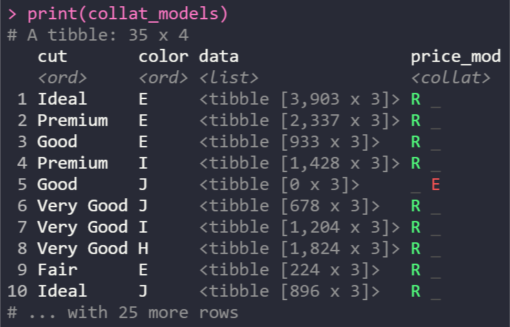

collat_models output, as seen in a terminal with colour

This `collateral` list-column is actually completely identical to the manually wrapped-and-mapped solution from `purrr`, other than the class name. The fancy tibble printing is totally separate from the content of the column and is handled using the `pillar` package (which provides extensions for tibble output), so if you’re already familiar with the `purrr` workflow you get immediate benefits, and if everything’s good you can pull the results out using `map(price_mod, 'result')`, just as before.

But `collateral` comes with additional helpers. You can get a quick `summary` of the problems:

```r
summary(collat_models$price_mod)
```

```
#> 35 elements in total.
#> 34 elements returned results, and
#> 1 element encountered errors.
```

You can also use the `tally_*()` functions in conjunction with [`dplyr::summarise()`](https://dplyr.tidyverse.org/reference/summarise.html) to get a count of each component (even if the top-level data frame grouped again!) or `has_*()` to [`dplyr::filter()`](https://dplyr.tidyverse.org/reference/filter.html) out the rows that didn’t make it (or the ones that did):

```r
collat_models %>%
  group_by(color) %>%
  summarise(
    n_res = tally_results(price_mod),
    n_err = tally_errors(price_mod))
```

```
#> # A tibble: 7 x 3
#>   color n_res n_err
#>   <ord> <int> <int>
#> 1 D         5     0
#> 2 E         5     0
#> 3 F         5     0
#> 4 G         5     0
#> 5 H         5     0
#> 6 I         5     0
#> 7 J         4     1
```

```r
collat_models %>%
  filter(has_errors(price_mod))
```

```
#> # A tibble: 1 x 4
#>   cut   color data             price_mod
#>   <ord> <ord> <list>           <collat>
#> 1 Good  J     <tibble [0 x 3]> _ E
```

Together, these tools make debugging problems drastically easier, even if you need to run a thousnad statistical models or analyse 500 datasets.